# **Stat 112 - Recitation 9**

> Ozancan Ozdemir - ozancan@metu.edu.tr

## **Data Cleaning with Pandas and Numpy**

The quality of the data is one of the most important conditions to produce a good results in data science, data analytics or data visualization. It does not matter either you have well-working algorithms or great tools, the quality of your output depends on your data input. That’s why it is important to be sure that the data under the study is properly refined.

Data cleaning is a foundational process in the data science lifecycle and its role cannot be overemphasized when trying to uncover insights and generate reliable answers. More often than not, data will always be dirty in the real world, and data cleaning cannot be completely avoided such that it is estimated that it takes 80% of the data analysis process.

[figure not shown]

This can involve finding and removing duplicates and incomplete records, and modifying data to rectify inaccurate records. Unclean or dirty data has always been a problem, yet we have seen an exponential rise in data generation over the last decade.

There is no absolute way to dictate the exact steps of the data cleansing process, as the process is different for each dataset. However, it’s important to create a template for your data cleansing process and make sure you’re doing it right every time.

**How do you clean data?**

> Step 1: Remove duplicate or irrelevant observations

> Step 2: Fix structural errors

> Step 3: Filter unwanted outliers

> Step 4: Handle missing data

**Components of quality data**

- Validity. The degree to which your data conforms to defined business rules or constraints.
- Accuracy. Ensure your data is close to the true values.
- Completeness. The degree to which all required data is known.
- Consistency. Ensure your data is consistent within the same dataset and/or across multiple data sets.
- Uniformity. The degree to which the data is specified using the same unit of measure.

Before data cleaning can properly be done, it is important to understand how it got dirty in the first place. Then, you determine your actions for cleaning.

Pandas and numpy includes functions being useful for data cleaning.

Prior to cleaning procedure, let's have a look at some concepts necessary for data cleaning; Missing data and string operators.

```python
#import the packages
import pandas as pd
import numpy as np
```

### **Missing Data**

Missing data occurs when no information is provided. Pandas provides some tools that makes dealing with missing easier.

In pandas, the missing observations have two representations.

- None: None is a Python singleton object that is often used for missing data in Python code.
- NaN : NaN (an acronym for Not a Number), is a special floating-point value recognized by all systems that use the standard IEEE floating-point representation

We can use following functions for missing analysis. i.e We can detect and replace the missing values with these functions

`df.isnull()`

`df.notnull()`

`df.dropna()`

`df.fillna()`

`df.replace()`

Consider the example,

```python
missing_data = pd.read_csv('https://metustat112.github.io/stolen_cars.csv',sep = ";")
print(missing_data)
```

```
                 Car   Number
0  Chevrolet Pick-Up  48206.0
1       Ford Pick-Up  47999.0
2        Honda Civic  31673.0
3       Honda Accord  30274.0
4       Toyota Camry  17270.0
5        GMC Pick-Up      NaN
6      Nissan Altima  14108.0
7         Honda CR-V      NaN
```

`isnull` and `notnull` works for the same purpose, but returns reverse outputs. While `isnull` returns `True` for missing values, `notnull` returns `True` for available values.

```python
missing_data.isnull()
```

|  | Car | Number |
| --- | --- | --- |
| 0 | False | False |
| 1 | False | False |
| 2 | False | False |
| 3 | False | False |
| 4 | False | False |
| 5 | False | True |
| 6 | False | False |
| 7 | False | True |

```python
missing_data.notnull()
```

|  | Car | Number |
| --- | --- | --- |
| 0 | True | True |
| 1 | True | True |
| 2 | True | True |
| 3 | True | True |
| 4 | True | True |
| 5 | True | False |
| 6 | True | True |
| 7 | True | False |

Instead of having a matrix including boolean values, we can directly compute the total number of missing values for each column in the data as given below.

```python
missing_data.isnull().sum()
```

```
Car       0
Number    2
dtype: int64
```

```python
##  Extra; Missing Percentage
new_df = pd.DataFrame(missing_data.isnull().sum())
new_df.columns = ['Missing Number']
new_df['Missing Percentage'] = (new_df['Missing Number']*100)/missing_data.shape[0]
new_df
```

|  | Missing Number | Missing Percentage |
| --- | --- | --- |
| Car | 0 | 0.0 |
| Number | 2 | 25.0 |

As seen above, we have two missing values in Number column. In other words, 25% of the observations in Number column is missing.

Apart from the column names, if we would like to compute the total number of the missing observations across the data,

```python
missing_data.isnull().sum().sum() #total number of missing observations
```

```
2
```

**Dealing with Missing Data**

The missing data problem is one of the hardest problem in data science. There are several approaches to handle with missingness, including both simple and complex cases.

Before remedying your missing problem in the data, you should figure out the source of the missing and pattern of the missing. After that, you should decide your strategies.

In this part, we will have a look at some of basic solutions. Note that better alternatives are available in practice.

The simplest but most unpreferable solution for missing problem is to drop the rows or columns .

You can remove the NA values with `dropna`

```python
missing_data.dropna(axis = 0) #axis = 0 removes the rows with na
#axis = 1 drops the columns with na
```

|  | Car | Number |
| --- | --- | --- |
| 0 | Chevrolet Pick-Up | 48206.0 |
| 1 | Ford Pick-Up | 47999.0 |
| 2 | Honda Civic | 31673.0 |
| 3 | Honda Accord | 30274.0 |
| 4 | Toyota Camry | 17270.0 |
| 6 | Nissan Altima | 14108.0 |

The imputing the missing values is better way, sure. You can fill your missing observations via different way. However, we will talk about the simplest way in the context of the course.

`fillna()` fills the all NA values with a user defined constant value.

```python
missing_data.fillna(0)
```

|  | Car | Number |
| --- | --- | --- |
| 0 | Chevrolet Pick-Up | 48206.0 |
| 1 | Ford Pick-Up | 47999.0 |
| 2 | Honda Civic | 31673.0 |
| 3 | Honda Accord | 30274.0 |
| 4 | Toyota Camry | 17270.0 |
| 5 | GMC Pick-Up | 0.0 |
| 6 | Nissan Altima | 14108.0 |
| 7 | Honda CR-V | 0.0 |

You can use the function to fill the missing values with descriptive statistics.

```python
mean = missing_data['Number'].mean()
median = missing_data['Number'].median()
mode = missing_data['Number'].mode()
print('Mean:',mean,'Median:',median,'Mode:',mode)
```

```
Mean: 31588.333333333332 Median: 30973.5 Mode: 0    14108.0
1    17270.0
2    30274.0
3    31673.0
4    47999.0
5    48206.0
dtype: float64
```

```python
missing_data['Number'].fillna(mean) #mean imputation
```

```
0    48206.000000
1    47999.000000
2    31673.000000
3    30274.000000
4    17270.000000
5    31588.333333
6    14108.000000
7    31588.333333
Name: Number, dtype: float64
```

```python
missing_data['Number'].fillna(median) #median imputation
```

```
0    48206.0
1    47999.0
2    31673.0
3    30274.0
4    17270.0
5    30973.5
6    14108.0
7    30973.5
Name: Number, dtype: float64
```

```python
missing_data['Number'].fillna(mode) #mode imputation
```

```
0    48206.0
1    47999.0
2    31673.0
3    30274.0
4    17270.0
5    48206.0
6    14108.0
7        NaN
Name: Number, dtype: float64
```

`replace` replaces the value in the specified unit.

```python
missing_data.replace(to_replace=np.nan,value=0) #replaces the all missing values with predefine value.
```

|  | Car | Number |
| --- | --- | --- |
| 0 | Chevrolet Pick-Up | 48206.0 |
| 1 | Ford Pick-Up | 47999.0 |
| 2 | Honda Civic | 31673.0 |
| 3 | Honda Accord | 30274.0 |
| 4 | Toyota Camry | 17270.0 |
| 5 | GMC Pick-Up | 0.0 |
| 6 | Nissan Altima | 14108.0 |
| 7 | Honda CR-V | 0.0 |

**Which one is better?**

Althogh it depends on the task, we can still make a generalization about these three imputation methods. If the numerical variables does not have any outlier, mean imputation can be used. If it has outlier observations, we can impute the median value instead of mean. On the other hand, if the missing value occurs in the object type variable. Then, we can use mode imputation. Mode imputation can be an option for a numerical variable when it has an approximately symmetric distribution.

#### **Example 1**

Import the `tao.csv` data.

```python
tao = pd.read_csv('tao.csv')
```

**a)** Calculate the total number of missing observations in the data.

```
177
```

**b)** Which column has the highest number of missing observations in the data?

```
Unnamed: 0           0
Year                 0
Latitude             0
Longitude            0
Sea.Surface.Temp     3
Air.Temp            81
Humidity            93
UWind                0
VWind                0
dtype: int64
```

**c)** Fill the missing values with the mean of the corresponding columns.

### **String Objects in Pandas**

String is a data type used to represent characters or texts rather than numbers. Pandas provides an easy way of applying string methods to whole columns which are just pandas series objects. `.str` accessor is used to implement the string arguments in Pandas.

Let's consider the given sample data frame.

```python
galatasaray_squad = pd.DataFrame({'Name':["Fernando,Muslera  ", "Léo,Dubois" ,"Patrick van,Aanholt","Mathias,Ross","Lucas,Torreira","Fredrik,Midtsjø",
"Kerem,Aktürkoğlu","Haris,Seferović ","Dries,Mertens",
"Yunus,Akgün","Emre,Taşdemir","Bafétimbi,Gomis",
"Berkan,Kutlu","Victor,nelsson","Milot,Rashica ",
"Sérgio,Oliveira","Yusuf,Demir","Okan,Kocuk",
"Emin,bayram","Abdülkerim,bardakcı","Barış Alper,Yılmaz",
"Baran,Aksaka","Juan,Mata","Hamza,Akman",
"Kazımcan,Karataş","Metehan,baltacı","Sacha,Boey",
"Mauro,Icardi  "]})
```

```python
galatasaray_squad['Name']
```

```
0      Fernando,Muslera
1              Léo,Dubois
2     Patrick van,Aanholt
3            Mathias,Ross
4          Lucas,Torreira
5         Fredrik,Midtsjø
6        Kerem,Aktürkoğlu
7        Haris,Seferović
8           Dries,Mertens
9             Yunus,Akgün
10          Emre,Taşdemir
11        Bafétimbi,Gomis
12           Berkan,Kutlu
13         Victor,nelsson
14         Milot,Rashica
15        Sérgio,Oliveira
16            Yusuf,Demir
17             Okan,Kocuk
18            Emin,bayram
19    Abdülkerim,bardakcı
20     Barış Alper,Yılmaz
21           Baran,Aksaka
22              Juan,Mata
23            Hamza,Akman
24       Kazımcan,Karataş
25        Metehan,baltacı
26             Sacha,Boey
27         Mauro,Icardi
Name: Name, dtype: object
```

**Removing unnecesary white spaces**

```python
galatasaray_squad['Name'] = galatasaray_squad['Name'].str.strip() # .str_strip() removes unccessary white spaces
galatasaray_squad['Name']
```

```
0        Fernando,Muslera
1              Léo,Dubois
2     Patrick van,Aanholt
3            Mathias,Ross
4          Lucas,Torreira
5         Fredrik,Midtsjø
6        Kerem,Aktürkoğlu
7         Haris,Seferović
8           Dries,Mertens
9             Yunus,Akgün
10          Emre,Taşdemir
11        Bafétimbi,Gomis
12           Berkan,Kutlu
13         Victor,nelsson
14          Milot,Rashica
15        Sérgio,Oliveira
16            Yusuf,Demir
17             Okan,Kocuk
18            Emin,bayram
19    Abdülkerim,bardakcı
20     Barış Alper,Yılmaz
21           Baran,Aksaka
22              Juan,Mata
23            Hamza,Akman
24       Kazımcan,Karataş
25        Metehan,baltacı
26             Sacha,Boey
27           Mauro,Icardi
Name: Name, dtype: object
```

**Changing the character formats**

```python
galatasaray_squad['Name'].str.upper().head(5) #Converts all characters to uppercase.
```

```
0       FERNANDO,MUSLERA
1             LÉO,DUBOIS
2    PATRICK VAN,AANHOLT
3           MATHIAS,ROSS
4         LUCAS,TORREIRA
Name: Name, dtype: object
```

```python
galatasaray_squad['Name'].str.lower().head(5) #Converts all characters to lowercase.
```

```
0       fernando,muslera
1             léo,dubois
2    patrick van,aanholt
3           mathias,ross
4         lucas,torreira
Name: Name, dtype: object
```

```python
galatasaray_squad['Name'].str.title().head(5) #Converts first character of each word to uppercase and remaining to lowercase.
```

```
0       Fernando,Muslera
1             Léo,Dubois
2    Patrick Van,Aanholt
3           Mathias,Ross
4         Lucas,Torreira
Name: Name, dtype: object
```

```python
galatasaray_squad['Name'].str.capitalize().head(5) #Converts first character to uppercase and remaining to lowercase.
```

```
0       Fernando,muslera
1             Léo,dubois
2    Patrick van,aanholt
3           Mathias,ross
4         Lucas,torreira
Name: Name, dtype: object
```

```python
galatasaray_squad['Name'] = galatasaray_squad['Name'].str.title() #fix the case problem.
```

**Splitting your string based on a pattern**

```python
galatasaray_squad['Name'].str.split(',', expand = True)
```

[output not shown]

```python
galatasaray_squad_list = galatasaray_squad['Name'].str.split(',', expand = True)
galatasaray_squad_list.columns = ['Name','Surname']
galatasaray_squad_list
```

[output not shown]

For more function, you can see [here](https://pandas.pydata.org/pandas-docs/stable/reference/api/pandas.Series.str.html)

#### **Exercise 2**

Please create the df1 by compling the following code. Please apply the following steps respectively.

- make the all strings in title format.
- seperate name and surname and add to the data as new columns

```python
df1 = pd.DataFrame({
    'name': ['alice smith','bob jones','charlie joneson','daisy white'],
    'age': [25,20,30,35]
})

df1
```

|  | name | age |
| --- | --- | --- |
| 0 | alice smith | 25 |
| 1 | bob jones | 20 |
| 2 | charlie joneson | 30 |
| 3 | daisy white | 35 |

|  | name | age |
| --- | --- | --- |
| 0 | Alice Smith | 25 |
| 1 | Bob Jones | 20 |
| 2 | Charlie Joneson | 30 |
| 3 | Daisy White | 35 |

|  | name | age | surname |
| --- | --- | --- | --- |
| 0 | Alice | 25 | Smith |
| 1 | Bob | 20 | Jones |
| 2 | Charlie | 30 | Joneson |
| 3 | Daisy | 35 | White |

### Let's get clean the data

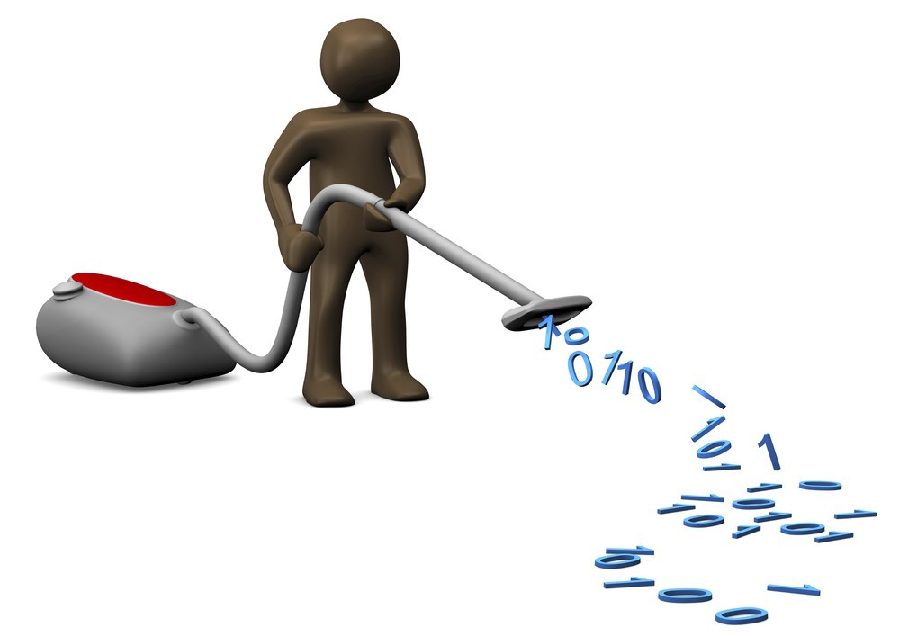

We should note that each data set will require different data cleaning procedures as stated above. The steps we are about to apply cover the most common problems likely to occur. In general, you use a few of them when you clean your data.

Before beginning the cleaning process, it's important to consider what your goals are and what you hope to learn or accomplish by analyzing the data. This will help you determine which data is relevant to your objectives, and which is not. By having a clear understanding of your objectives, you can ensure that the data you are cleaning and analyzing is useful and relevant.

With that in mind, let’s get started.

**Step 1:** Please read `dirty_data.xlsx`. Remember that we used a similar data in Recitation 3.

```python
dirtydata = pd.read_excel('dirtydata.xlsx')
```

**Step 2:** After reading your data, represent the couple of observations from both top and bottom to be sure that you import the data correctly, and examine the variables. Then, check the variable type.

```python
dirtydata.head()#first five observations
```

|  | Id | GenDer | AgE | Software_ | TIME | Unit | BuY | SPEND | EARN | Download | Dates |
| --- | --- | --- | --- | --- | --- | --- | --- | --- | --- | --- | --- |
| 0 | 1 | Male | 35 - 50 | IOS | 2.0 | hour | Yes | 13.0 | 1 | 1.0 | 2019-02-26 00:00:00 |
| 1 | 2 | Male | 25 - 35 | IOS | 1.0 | hour | No | 16.0 | 3 | NaN | 26 Feb 2019 |
| 2 | 3 | Male | 25 - 35 | IOS | 4.0 | hour | YES | 15.0 | 2 | NaN | 2019-02-26 00:00:00 |
| 3 | 4 | Male | 18 - 25 | IOS | 2.0 | hour | YES | 20.0 | 6 | NaN | 2019-02-26 00:00:00 |
| 4 | 5 | MALE | 18 - 25 | Ios | 1.5 | hour | No | 18.0 | 7 | NaN | 2019-02-26 00:00:00 |

```python
dirtydata.tail() #last five observations
```

|  | Id | GenDer | AgE | Software_ | TIME | Unit | BuY | SPEND | EARN | Download | Dates |
| --- | --- | --- | --- | --- | --- | --- | --- | --- | --- | --- | --- |
| 96 | 97 | MALE_ | 35 - 50 | Apple IOS | 2.0 | hour | Yes | 18.0 | 5 | NaN | 2019-02-26 00:00:00 |
| 97 | 98 | F | 25 - 35 | Apple IOS | 2.0 | hour | No | 15.0 | 8 | NaN | 2019-02-26 00:00:00 |
| 98 | 99 | Female | 25 - 35 | Apple IOS | 1.0 | hour | Yes | 12.0 | 6 | NaN | 2019-02-26 00:00:00 |
| 99 | 100 | Female | 18 - 25 | Apple IOS | 1.0 | hour | No | 16.0 | 10 | NaN | 2019-02-26 00:00:00 |
| 100 | 101 | Female | 18 - 25 | Apple IOS | 0.0 | hour | No | 16.0 | 9999999999999 | 1.0 | 26 Feb 2019 |

```python
dirtydata.info()
```

```
<class 'pandas.core.frame.DataFrame'>
RangeIndex: 101 entries, 0 to 100
Data columns (total 11 columns):
 #   Column     Non-Null Count  Dtype
---  ------     --------------  -----
 0   Id         101 non-null    int64
 1   GenDer     101 non-null    object
 2   AgE        101 non-null    object
 3   Software_  101 non-null    object
 4   TIME       101 non-null    float64
 5   Unit       101 non-null    object
 6   BuY        101 non-null    object
 7   SPEND      96 non-null     float64
 8   EARN       101 non-null    int64
 9   Download   4 non-null      float64
 10  Dates      101 non-null    object
dtypes: float64(3), int64(2), object(6)
memory usage: 8.8+ KB
```

The data has imported correctly. It is seen that we have some problems for column names. The values under the columns are also problematic in addition to the missingness.

**Step 3:** Fix the column names to provide an ease for the further steps.

```python
dirtydata.columns = dirtydata.columns.str.title()
dirtydata.columns
```

```
Index(['Id', 'Gender', 'Age', 'Software_', 'Time', 'Unit', 'Buy', 'Spend',
       'Earn', 'Download', 'Dates'],
      dtype='object')
```

After fixing the case problem, remove the quotation mark in Software.

```python
dirtydata = dirtydata.rename({'Software_': 'Software'},axis = "columns")
dirtydata.columns
```

```
Index(['Id', 'Gender', 'Age', 'Software', 'Time', 'Unit', 'Buy', 'Spend',
       'Earn', 'Download', 'Dates'],
      dtype='object')
```

**Step 4:** Check the duplicates and remove them if it is not necessary.

```python
dirtydata.duplicated().sum() #.duplicated detects the rows including the same observations
```

[output not shown]

```python
dirtydata = dirtydata.drop_duplicates() #remove the duplicated row.
```

```python
dirtydata.duplicated().sum() #no duplicates
```

```
0
```

**Step 5:** Get rid of the irrelevant strings in the values.

In this data, we are working with string objects. The best way to examine the values of strings is to create their **frequency tables.**

As in many problems, there are several ways to create a frequency table using Pandas. One of them is illustrated below.

```python
for i in dirtydata.select_dtypes(include = 'object').columns:
  print(dirtydata[i].value_counts())
```

```
Male        59
M           14
MALE        12
Female       5
F            4
FEMALE       3
FEMALE..     2
MALE_        2
Name: Gender, dtype: int64
18 - 25    53
25 - 35    33
35 - 50    12
1825        2
18-  25     1
Name: Age, dtype: int64
Android      52
ANDROID      16
Apple        15
Apple IOS     6
 IOS          5
  IOS         2
 Ios          1
iphone        1
ıOS           1
Huawei        1
Sony          1
Name: Software, dtype: int64
hour      91
minute     8
second     2
Name: Unit, dtype: int64
No       54
Yes      39
HAYIR     3
YES       2
 No       2
  No      1
Name: Buy, dtype: int64
2019-02-26 00:00:00    92
26 Feb 2019             9
Name: Dates, dtype: int64
```

The frequency table shows that Gender, Age, Software and Buy columns have the irrelevant punctuations or strings to be removed or replaced.

Note that you should have at least introductory level regex experience for punctuations.

**Gender**

```python
dirtydata['Gender'] = dirtydata['Gender'].str.replace("\..","",regex=True) #remove ..
dirtydata['Gender'] = dirtydata['Gender'].str.replace("\_","",regex=True)#remove _
dirtydata['Gender'].value_counts()
```

```
Male      59
MALE      14
M         14
FEMALE     5
Female     5
F          4
Name: Gender, dtype: int64
```

```python
dirtydata['Gender'].loc[dirtydata['Gender'] == 'M'] = 'Male' #replace the M's with Male
dirtydata['Gender'].loc[dirtydata['Gender'] == 'F'] = 'Female' #replace the F's with Females
dirtydata['Gender'] = dirtydata['Gender'].str.title() #Make them title
dirtydata['Gender'].value_counts()
```

```
Male      87
Female    14
Name: Gender, dtype: int64
```

**Age**

```python
dirtydata['Age'].loc[dirtydata['Age']=="1825"] = 18-25
dirtydata['Age'].value_counts()
```

```
18 - 25    53
25 - 35    33
35 - 50    12
1825        2
18-  25     1
Name: Age, dtype: int64
```

```python
dirtydata['Age'] = dirtydata['Age'].str.replace("1825","18-25")
dirtydata['Age'].value_counts()
```

```
18 - 25    53
25 - 35    33
35 - 50    12
18-  25     1
Name: Age, dtype: int64
```

**Software**

```python
dirtydata['Software'] = dirtydata['Software'].str.replace("Apple IOS","Ios")
dirtydata['Software'] = dirtydata['Software'].str.replace("Apple","Ios")
dirtydata['Software'] = dirtydata['Software'].str.replace("iphone","Ios")
dirtydata['Software'].value_counts()
```

```
Android    52
Ios        22
ANDROID    16
 IOS        5
  IOS       2
 Ios        1
ıOS         1
Huawei      1
Sony        1
Name: Software, dtype: int64
```

**Buy**

```python
dirtydata['Buy'].loc[dirtydata['Buy']=="HAYIR"]  = 'No'
dirtydata['Buy'].value_counts()
```

[output not shown]

**Step 6:** Remove the white spaces in the string values.

The frequency table shows that Age, Software and Buy have unnecessary white spaces in the values.

```python
dirtydata['Age'] = dirtydata['Age'].str.strip()
dirtydata['Software'] = dirtydata['Software'].str.strip()
dirtydata['Buy'] = dirtydata['Buy'].str.strip()
print(dirtydata['Age'].value_counts())
print(dirtydata['Software'].value_counts())
print(dirtydata['Buy'].value_counts())
```

```
18 - 25    53
25 - 35    33
35 - 50    12
18-  25     1
Name: Age, dtype: int64
Android    52
Ios        23
ANDROID    16
IOS         7
ıOS         1
Huawei      1
Sony        1
Name: Software, dtype: int64
No     60
Yes    39
YES     2
Name: Buy, dtype: int64
```

```python
dirtydata['Age'] = dirtydata['Age'].str.replace("18-  25","18 - 25")
```

**Step 7:** Make sure that all strings are in the same format (e.g all in title)

The consistency in the format of the string values under gender column is satisfied. The problem occurs in only software and buy columns.

**Software**

```python
dirtydata['Software'] = dirtydata['Software'].str.title()
dirtydata['Software'].value_counts()
```

```
Android    68
Ios        31
Huawei      1
Sony        1
Name: Software, dtype: int64
```

**Buy**

```python
dirtydata['Buy'] = dirtydata['Buy'].str.title()
dirtydata['Buy'].value_counts()
```

```
No     60
Yes    41
Name: Buy, dtype: int64
```

**Step 8:** Examine the descriptive statistics of the numerical variables. Search for any unusual behavior. Search also outliers, if there are outliers, replace them with the median.

```python
dirtydata.describe().transpose()
```

|  | count | mean | std | min | 25% | 50% | 75% | max |
| --- | --- | --- | --- | --- | --- | --- | --- | --- |
| Id | 101.0 | 5.099010e+01 | 2.929590e+01 | 1.0 | 26.0 | 51.0 | 76.0 | 1.010000e+02 |
| Time | 101.0 | 1.166089e+02 | 7.969932e+02 | -2.0 | 1.0 | 2.0 | 3.0 | 7.200000e+03 |
| Spend | 96.0 | 1.493750e+01 | 3.131546e+00 | 10.0 | 12.0 | 15.0 | 18.0 | 2.000000e+01 |
| Earn | 101.0 | 9.901980e+10 | 9.950362e+11 | 1.0 | 3.0 | 5.0 | 8.0 | 1.000000e+13 |
| Download | 4.0 | 1.000000e+00 | 0.000000e+00 | 1.0 | 1.0 | 1.0 | 1.0 | 1.000000e+00 |

The descriptive statistics show that we have unlogical value in time (-2), and in earn (9999999999999). Let's make them correct.

```python
dirtydata['Time'].loc[dirtydata['Time']== -2] = 2
dirtydata['Earn'].loc[dirtydata['Earn']==dirtydata['Earn'].values.max()] = dirtydata['Earn'].values.median()
dirtydata['Earn'].loc[dirtydata['Earn']==dirtydata['Earn'].values.max()] = dirtydata['Earn'].values.median()
```

```python
dirtydata.describe().transpose()
```

|  | count | mean | std | min | 25% | 50% | 75% | max |
| --- | --- | --- | --- | --- | --- | --- | --- | --- |
| Id | 101.0 | 50.990099 | 29.295902 | 1.0 | 26.0 | 51.0 | 76.0 | 101.0 |
| Time | 101.0 | 116.727723 | 796.975654 | 0.0 | 1.0 | 2.0 | 3.0 | 7200.0 |
| Spend | 96.0 | 14.937500 | 3.131546 | 10.0 | 12.0 | 15.0 | 18.0 | 20.0 |
| Earn | 101.0 | 4.435644 | 2.826361 | 0.0 | 2.0 | 4.0 | 7.0 | 9.0 |
| Download | 4.0 | 1.000000 | 0.000000 | 1.0 | 1.0 | 1.0 | 1.0 | 1.0 |

**Step 9:** Search for uniformity. That is the measured variables must be in the same unit.

In this data, we have time and unit variable. Note that we have minute and second in unit colums where the majority were dominated by hour. So, let's convert them into hour and change the unit name.

```python
dirtydata['Time'].loc[dirtydata['Unit'] =="minute"] = dirtydata['Time'].loc[dirtydata['Unit'] =="minute"]/60
dirtydata['Time'].loc[dirtydata['Unit'] =="second"] = dirtydata['Time'].loc[dirtydata['Unit'] =="second"]/3600
```

```python
dirtydata['Unit'] = dirtydata['Unit'].str.replace('minute','Hour')
dirtydata['Unit'] = dirtydata['Unit'].str.replace('second','Hour')
dirtydata['Unit'] = dirtydata['Unit'].str.title()
dirtydata['Unit'].value_counts()
```

```
Hour    101
Name: Unit, dtype: int64
```

**Step 10:** Search for the missing values. Either impute or drop the observations based on the missing percentage.

Let's create a missing table for the data.

```python
new_df = pd.DataFrame(dirtydata.isnull().sum())
new_df.columns = ['Missing Number']
new_df['Missing Percentage'] = (new_df['Missing Number']*100)/dirtydata.shape[0]
new_df
```

|  | Missing Number | Missing Percentage |
| --- | --- | --- |
| Id | 0 | 0.000000 |
| Gender | 0 | 0.000000 |
| Age | 2 | 1.980198 |
| Software | 0 | 0.000000 |
| Time | 0 | 0.000000 |
| Unit | 0 | 0.000000 |
| Buy | 0 | 0.000000 |
| Spend | 5 | 4.950495 |
| Earn | 0 | 0.000000 |
| Download | 97 | 96.039604 |
| Dates | 0 | 0.000000 |

It is seen that we have 2 missings in one object variable; age, 5 missing variables in spend. On the other hand, 96% of the observations in Download are missing.

- Mode imputation for age since it is a object variable.
- Mean imputation for spend since the data does not have outlier.
- Drop the download column

**Age**

```python
mode_for_age = dirtydata['Age'].value_counts().idxmax()#gives you the level with highest frequency
dirtydata['Age'] = dirtydata['Age'].fillna(mode_for_age)
```

[output not shown]

**Spend**

```python
mean_for_spend = dirtydata['Spend'].values.mean()
dirtydata['Spend'] = dirtydata['Spend'].fillna(mean_for_spend)
```

**Download**

```python
dirtydata = dirtydata.drop('Download',axis = 1)
dirtydata.head()
```

|  | Id | Gender | Age | Software | Time | Unit | Buy | Spend | Earn | Dates |
| --- | --- | --- | --- | --- | --- | --- | --- | --- | --- | --- |
| 0 | 1 | Male | 35 - 50 | Ios | 2.0 | Hour | Yes | 13.0 | 1 | 2019-02-26 00:00:00 |
| 1 | 2 | Male | 25 - 35 | Ios | 1.0 | Hour | No | 16.0 | 3 | 26 Feb 2019 |
| 2 | 3 | Male | 25 - 35 | Ios | 4.0 | Hour | Yes | 15.0 | 2 | 2019-02-26 00:00:00 |
| 3 | 4 | Male | 18 - 25 | Ios | 2.0 | Hour | Yes | 20.0 | 6 | 2019-02-26 00:00:00 |
| 4 | 5 | Male | 18 - 25 | Ios | 1.5 | Hour | No | 18.0 | 7 | 2019-02-26 00:00:00 |

**Step 11:** Examine the date type object and be sure that all observations in the same format.

Although we have a date column, it is not a date type data. It is an object data.

```python
dirtydata['Dates'].loc[dirtydata['Dates'] != dirtydata['Dates'].value_counts().idxmax()] = dirtydata['Dates'].value_counts().idxmax()
dirtydata['Dates'].value_counts()
```

```
2019-02-26    101
Name: Dates, dtype: int64
```

```python
dirtydata['Dates'] = pd.to_datetime(dirtydata['Dates']) #change the object time
```

```python
dirtydata.info()
```

[output not shown]

```python
dirtydata.head()
```

|  | Id | Gender | Age | Software | Time | Unit | Buy | Spend | Earn | Dates |
| --- | --- | --- | --- | --- | --- | --- | --- | --- | --- | --- |
| 0 | 1 | Male | 35 - 50 | Ios | 2.0 | Hour | Yes | 13.0 | 1 | 2019-02-26 |
| 1 | 2 | Male | 25 - 35 | Ios | 1.0 | Hour | No | 16.0 | 3 | 2019-02-26 |
| 2 | 3 | Male | 25 - 35 | Ios | 4.0 | Hour | Yes | 15.0 | 2 | 2019-02-26 |
| 3 | 4 | Male | 18 - 25 | Ios | 2.0 | Hour | Yes | 20.0 | 6 | 2019-02-26 |
| 4 | 5 | Male | 18 - 25 | Ios | 1.5 | Hour | No | 18.0 | 7 | 2019-02-26 |

We cleaned the data!!!

[figure not shown]

Now, we will export the data for the future use.

```python
dirtydata.to_csv("cleandata.csv") #export the clean data
```

#### **Example 3**

Import the `ex3_data.xlsx` data. Detect the problems and clean the data using pandas functions.

```python
ex3 = pd.read_excel('ex3_data.xlsx')
ex3.head()
```

|  | Time | TRICK | gender | AGE | unit | country | Sta*te | Grand | Income | SpEND | Status |
| --- | --- | --- | --- | --- | --- | --- | --- | --- | --- | --- | --- |
| 0 | 10.24.2016 | No | male | 22 | year | Canada | Ontario | JOY | 1502.0 | 1019.0 | Rich |
| 1 | 10.24.2016 | No | Male | 45 | year | usa | il | MEH | 1948.0 | 567.0 | Rich |
| 2 | 10.24.2016 | No | Female | 48 | year | US | Colorado | JOY | 2405.0 | 813.0 | NaN |
| 3 | 10.24.2016 | No | Male | 57 | year | usa | il | JOY | 2372.0 | 1053.0 | NaN |
| 4 | 10.24.2016 | Yes | Male | 42 | year | USA | ontario | MEH | 2518.0 | 235.0 | NaN |